# (Prosper Loan Data Exploration)

## Preliminary Wrangling

> This data set contains 113,937 loans with 81 variables on each loan, including loan amount, borrower rate (or interest rate), current loan status, borrower income, and many others.

```python
# import all packages and set plots to be embedded inline
import numpy as np
import pandas as pd
import matplotlib.pyplot as plt
import seaborn as sb

%matplotlib inline
```

```python
loan=pd.read_csv('prosperLoanData.csv')
```

```python
print(loan.shape)
print(loan.dtypes)
loan.head(10)
```

```
(113937, 81)
ListingKey                      object
ListingNumber                    int64
ListingCreationDate             object
CreditGrade                     object
Term                             int64
                                ...
PercentFunded                  float64
Recommendations                  int64
InvestmentFromFriendsCount       int64
InvestmentFromFriendsAmount    float64
Investors                        int64
Length: 81, dtype: object
```

|  | ListingKey | ListingNumber | ListingCreationDate | CreditGrade | Term | LoanStatus | ClosedDate | BorrowerAPR | BorrowerRate | LenderYield | ... | LP_ServiceFees | LP_CollectionFees | LP_GrossPrincipalLoss | LP_NetPrincipalLoss | LP_NonPrincipalRecoverypayments | PercentFunded | Recommendations | InvestmentFromFriendsCount | InvestmentFromFriendsAmount | Investors |
| --- | --- | --- | --- | --- | --- | --- | --- | --- | --- | --- | --- | --- | --- | --- | --- | --- | --- | --- | --- | --- | --- |
| 0 | 1021339766868145413AB3B | 193129 | 2007-08-26 19:09:29.263000000 | C | 36 | Completed | 2009-08-14 00:00:00 | 0.16516 | 0.1580 | 0.1380 | ... | -133.18 | 0.0 | 0.0 | 0.0 | 0.0 | 1.0 | 0 | 0 | 0.0 | 258 |
| 1 | 10273602499503308B223C1 | 1209647 | 2014-02-27 08:28:07.900000000 | NaN | 36 | Current | NaN | 0.12016 | 0.0920 | 0.0820 | ... | 0.00 | 0.0 | 0.0 | 0.0 | 0.0 | 1.0 | 0 | 0 | 0.0 | 1 |
| 2 | 0EE9337825851032864889A | 81716 | 2007-01-05 15:00:47.090000000 | HR | 36 | Completed | 2009-12-17 00:00:00 | 0.28269 | 0.2750 | 0.2400 | ... | -24.20 | 0.0 | 0.0 | 0.0 | 0.0 | 1.0 | 0 | 0 | 0.0 | 41 |
| 3 | 0EF5356002482715299901A | 658116 | 2012-10-22 11:02:35.010000000 | NaN | 36 | Current | NaN | 0.12528 | 0.0974 | 0.0874 | ... | -108.01 | 0.0 | 0.0 | 0.0 | 0.0 | 1.0 | 0 | 0 | 0.0 | 158 |
| 4 | 0F023589499656230C5E3E2 | 909464 | 2013-09-14 18:38:39.097000000 | NaN | 36 | Current | NaN | 0.24614 | 0.2085 | 0.1985 | ... | -60.27 | 0.0 | 0.0 | 0.0 | 0.0 | 1.0 | 0 | 0 | 0.0 | 20 |
| 5 | 0F05359734824199381F61D | 1074836 | 2013-12-14 08:26:37.093000000 | NaN | 60 | Current | NaN | 0.15425 | 0.1314 | 0.1214 | ... | -25.33 | 0.0 | 0.0 | 0.0 | 0.0 | 1.0 | 0 | 0 | 0.0 | 1 |
| 6 | 0F0A3576754255009D63151 | 750899 | 2013-04-12 09:52:56.147000000 | NaN | 36 | Current | NaN | 0.31032 | 0.2712 | 0.2612 | ... | -22.95 | 0.0 | 0.0 | 0.0 | 0.0 | 1.0 | 0 | 0 | 0.0 | 1 |
| 7 | 0F1035772717087366F9EA7 | 768193 | 2013-05-05 06:49:27.493000000 | NaN | 36 | Current | NaN | 0.23939 | 0.2019 | 0.1919 | ... | -69.21 | 0.0 | 0.0 | 0.0 | 0.0 | 1.0 | 0 | 0 | 0.0 | 1 |
| 8 | 0F043596202561788EA13D5 | 1023355 | 2013-12-02 10:43:39.117000000 | NaN | 36 | Current | NaN | 0.07620 | 0.0629 | 0.0529 | ... | -16.77 | 0.0 | 0.0 | 0.0 | 0.0 | 1.0 | 0 | 0 | 0.0 | 1 |
| 9 | 0F043596202561788EA13D5 | 1023355 | 2013-12-02 10:43:39.117000000 | NaN | 36 | Current | NaN | 0.07620 | 0.0629 | 0.0529 | ... | -16.77 | 0.0 | 0.0 | 0.0 | 0.0 | 1.0 | 0 | 0 | 0.0 | 1 |

10 rows × 81 columns

```python
col=['Term','BorrowerAPR','BorrowerRate','LoanOriginalAmount','LoanStatus','ProsperRating (Alpha)','ProsperRating (numeric)','MonthlyLoanPayment','EmploymentStatus']
sub_loan=loan[col]
```

```python
sub_loan.head(5)
```

|  | Term | BorrowerAPR | BorrowerRate | LoanOriginalAmount | LoanStatus | ProsperRating (Alpha) | ProsperRating (numeric) | MonthlyLoanPayment | EmploymentStatus |
| --- | --- | --- | --- | --- | --- | --- | --- | --- | --- |
| 0 | 36 | 0.16516 | 0.1580 | 9425 | Completed | NaN | NaN | 330.43 | Self-employed |
| 1 | 36 | 0.12016 | 0.0920 | 10000 | Current | A | 6.0 | 318.93 | Employed |
| 2 | 36 | 0.28269 | 0.2750 | 3001 | Completed | NaN | NaN | 123.32 | Not available |
| 3 | 36 | 0.12528 | 0.0974 | 10000 | Current | A | 6.0 | 321.45 | Employed |
| 4 | 36 | 0.24614 | 0.2085 | 15000 | Current | D | 3.0 | 563.97 | Employed |

```python
sub_loan['ProsperRating (Alpha)'].value_counts()
```

```
C     18345
B     15581
A     14551
D     14274
E      9795
HR     6935
AA     5372
Name: ProsperRating (Alpha), dtype: int64
```

```python
sub_loan.describe()
```

|  | Term | BorrowerAPR | BorrowerRate | LoanOriginalAmount | ProsperRating (numeric) | MonthlyLoanPayment |
| --- | --- | --- | --- | --- | --- | --- |
| count | 113937.000000 | 113912.000000 | 113937.000000 | 113937.00000 | 84853.000000 | 113937.000000 |
| mean | 40.830248 | 0.218828 | 0.192764 | 8337.01385 | 4.072243 | 272.475783 |
| std | 10.436212 | 0.080364 | 0.074818 | 6245.80058 | 1.673227 | 192.697812 |
| min | 12.000000 | 0.006530 | 0.000000 | 1000.00000 | 1.000000 | 0.000000 |
| 25% | 36.000000 | 0.156290 | 0.134000 | 4000.00000 | 3.000000 | 131.620000 |
| 50% | 36.000000 | 0.209760 | 0.184000 | 6500.00000 | 4.000000 | 217.740000 |
| 75% | 36.000000 | 0.283810 | 0.250000 | 12000.00000 | 5.000000 | 371.580000 |
| max | 60.000000 | 0.512290 | 0.497500 | 35000.00000 | 7.000000 | 2251.510000 |

```python
sub_loan.info()
```

```
<class 'pandas.core.frame.DataFrame'>
RangeIndex: 113937 entries, 0 to 113936
Data columns (total 9 columns):
Term                       113937 non-null int64
BorrowerAPR                113912 non-null float64
BorrowerRate               113937 non-null float64
LoanOriginalAmount         113937 non-null int64
LoanStatus                 113937 non-null object
ProsperRating (Alpha)      84853 non-null object
ProsperRating (numeric)    84853 non-null float64
MonthlyLoanPayment         113937 non-null float64
EmploymentStatus           111682 non-null object
dtypes: float64(4), int64(2), object(3)
memory usage: 7.8+ MB
```

### What is the structure of your dataset?

> The dataset contains 113,937 loans with 81 features

### What is/are the main feature(s) of interest in your dataset?

> I am interested in what affects the borrower’s APR

### What features in the dataset do you think will help support your investigation into your feature(s) of interest?

> i think these features will help me in my exporation analysis Term,BorrowerAPR,BorrowerRate,LoanOriginalAmount,LoanStatus,ProsperRating (Alpha),ProsperRating (numeric),MonthlyLoanPayment,EmploymentStatus

## Univariate Exploration

> In this section, investigate distributions of individual variables. If you see unusual points or outliers, take a deeper look to clean things up and prepare yourself to look at relationships between variables.

#### Borrower APR

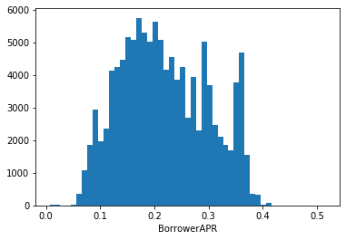

```python
#investigate distribution of borrower APR
bins=np.arange(sub_loan['BorrowerAPR'].min(),sub_loan['BorrowerAPR'].max()+0.01,0.01)
plt.hist(data = sub_loan, x = 'BorrowerAPR',bins=bins);
plt.xlabel('BorrowerAPR')
```

As we see BorrowerAPR distribution is mulitmodel there are several peaks small peak at 0.1 and large one at 0.2 another 2 peaks at 0.3 and 0.35.

#### Borrower Rate

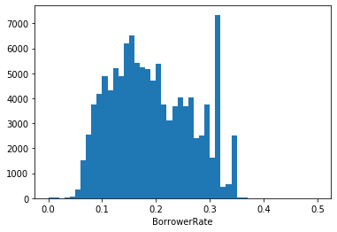

```python
#investigate distribution of BorrowerRate
bins=np.arange(sub_loan['BorrowerRate'].min(),sub_loan['BorrowerRate'].max()+0.01,0.01)
plt.hist(data = sub_loan, x = 'BorrowerRate',bins=bins);
plt.xlabel('BorrowerRate')
```

distribution of BorrowerRate and BorrowerAPR are slightly similar

#### Monthly Loan Payment

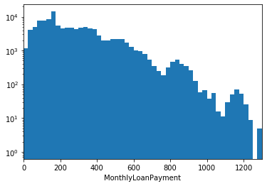

```python
#investigate distribution of MonthlyLoanPayment
bins=np.arange(sub_loan['MonthlyLoanPayment'].min(),sub_loan['MonthlyLoanPayment'].max()+25,25)
plt.hist(data = sub_loan, x = 'MonthlyLoanPayment',bins=bins);
plt.xlabel('MonthlyLoanPayment')
plt.xlim([0,1300])
plt.yscale('log')
```

the distributions are skewed to the right

#### Loan Original Amount

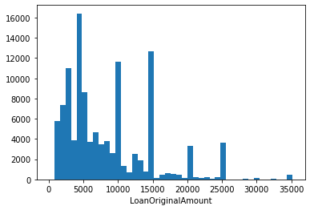

```python
#investigate distribution of LoanOriginalAmount
bins=np.arange(0,sub_loan['LoanOriginalAmount'].max()+800,800)
plt.hist(data = sub_loan, x = 'LoanOriginalAmount',bins=bins);
plt.xlabel('LoanOriginalAmount')
```

there are several large peaks at 2500,5000,10000,15000,20000,25000 we can find every peak was increased by 5000 it increases at the same rate.

#### prosper rating

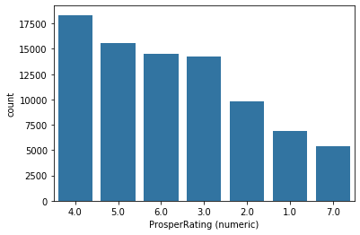

```python
base_color = sb.color_palette()[0]
score_order=sub_loan['ProsperRating (numeric)'].value_counts().index
sb.countplot(data=sub_loan, x='ProsperRating (numeric)', color=base_color, order=score_order);
```

#### loan status

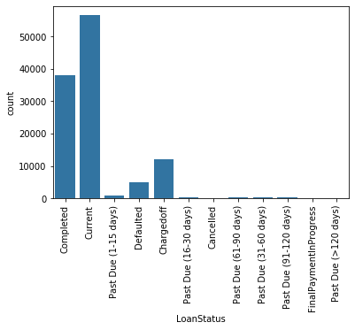

```python
#ditribution of loanstatus
score_order=sub_loan['LoanStatus'].value_counts().index
sb.countplot(data=sub_loan, x='LoanStatus', color=base_color);
plt.xticks(rotation=90)
```

current loan status tend to have the most count

### Discuss the distribution(s) of your variable(s) of interest. Were there any unusual points? Did you need to perform any transformations?

> As we see BorrowerAPR distribution is mulitmodel there are several peaks small peak at 0.1 and large one at 0.2 another 2 peaks at 0.3 and 0.35. and distribution of BorrowerRate and BorrowerAPR are slightly similar

### Of the features you investigated, were there any unusual distributions? Did you perform any operations on the data to tidy, adjust, or change the form of the data? If so, why did you do this?

> the distribution of MonthlyLoanPayment is skewed to the right. Most stated monthly payment are less than 1300, so i used xlim function from zero to 1300, the variable took on a large range of values, so I looked at the data using a log transform.

## Bivariate Exploration

```python
numeric_vars=['BorrowerAPR', 'LoanOriginalAmount','MonthlyLoanPayment']
category_vars=['Term','LoanStatus','EmploymentStatus']
```

#### correlation between variables

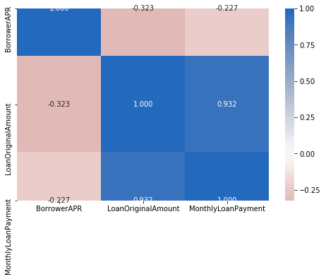

```python
# correlation(matrices) plot
plt.figure(figsize = [8,5])
sb.heatmap(sub_loan[numeric_vars].corr(), annot = True, fmt = '.3f',
           cmap = 'vlag_r', center = 0)
plt.show()
```

```
C:\Users\Alaa Elsherif\Anaconda3\lib\site-packages\numpy\lib\histograms.py:839: RuntimeWarning: invalid value encountered in greater_equal
  keep = (tmp_a >= first_edge)
C:\Users\Alaa Elsherif\Anaconda3\lib\site-packages\numpy\lib\histograms.py:840: RuntimeWarning: invalid value encountered in less_equal
  keep &= (tmp_a <= last_edge)
```

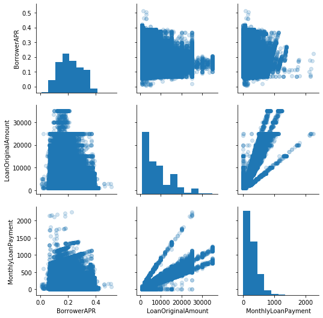

```python
g=sb.PairGrid(data=sub_loan,vars=['BorrowerAPR','LoanOriginalAmount','MonthlyLoanPayment']);
g.map_diag(plt.hist)
g.map_offdiag(plt.scatter,alpha=0.2)
```

#### Correlation between Monthly Loan Payment and Loan Original Amount

```python
sub_loan['MonthlyLoanPayment'].describe()
```

```
count    113937.000000
mean        272.475783
std         192.697812
min           0.000000
25%         131.620000
50%         217.740000
75%         371.580000
max        2251.510000
Name: MonthlyLoanPayment, dtype: float64
```

```python
sub_loan['LoanOriginalAmount'].describe()
```

```
count    113937.00000
mean       8337.01385
std        6245.80058
min        1000.00000
25%        4000.00000
50%        6500.00000
75%       12000.00000
max       35000.00000
Name: LoanOriginalAmount, dtype: float64
```

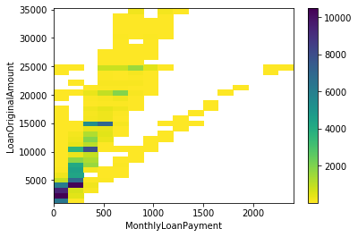

```python
# Specify bin edges
bins_x = np.arange(0, 2251+150,150)
bins_y = np.arange(1000, 35000+900,900)

plt.hist2d(data = sub_loan, x = 'MonthlyLoanPayment', y = 'LoanOriginalAmount', cmin=0.5, cmap='viridis_r', bins = [bins_x, bins_y])
plt.colorbar()
plt.xlabel('MonthlyLoanPayment')
plt.ylabel('LoanOriginalAmount');
```

There is a strong correlation between both variables as LoanOriginalAmount increases, MonthlyLoanPayment increases. most likely monthly payment 1000$ and few how pay more than that.

#### EmploymentStatus VS Term

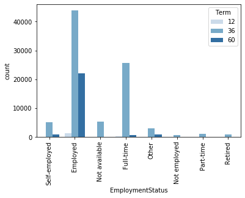

```python
sb.countplot(data = sub_loan, x = 'EmploymentStatus', hue = 'Term',palette = 'Blues');
plt.xticks(rotation=90)
```

#### Correlation between BorrowerARP and original loan amount

we want to see how they are related

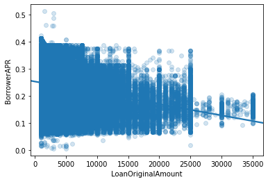

```python
sb.regplot(data=sub_loan,x='LoanOriginalAmount',y='BorrowerAPR',scatter_kws={'alpha':1/5})
plt.xlabel('LoanOriginalAmount')
plt.ylabel('BorrowerAPR')
```

here there is a negative correlation between the two variables. when loan amount increases the borrowerARP decreases

## Multivariate Exploration

### How Term affect MonthlyLoanPayment and LoanOriginalAmount

```
C:\Users\Alaa Elsherif\Anaconda3\lib\site-packages\seaborn\axisgrid.py:230: UserWarning: The `size` paramter has been renamed to `height`; please update your code.
  warnings.warn(msg, UserWarning)
```

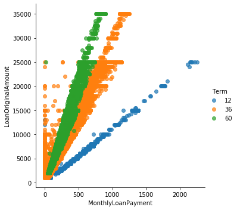

```python
g = sb.FacetGrid(data = sub_loan, hue = 'Term', size = 5)
g.map(plt.scatter, 'MonthlyLoanPayment', 'LoanOriginalAmount',alpha=0.7)
g.add_legend()
```

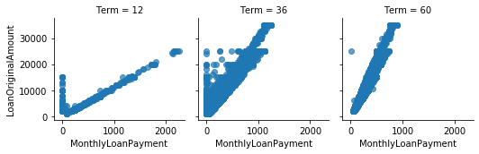

```python
plt.figure(figsize=(10,8))
g = sb.FacetGrid(data = sub_loan, col = 'Term', size = 2.5,
                margin_titles = True)
g.map(plt.scatter, 'MonthlyLoanPayment', 'LoanOriginalAmount',alpha=0.7)
```

it seams that term affect on both two variables and when loan amount increases so as term variable increse monthly payment decrease.

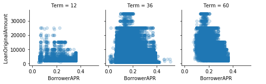

```python
#plt.figure(figsize=(10,8))
g = sb.FacetGrid(data = sub_loan, col = 'Term', size = 2.5,
                margin_titles = True)
g.map(plt.scatter, 'BorrowerAPR', 'LoanOriginalAmount',alpha=0.2)
g.add_legend();
```

### Talk about some of the relationships you observed in this part of the investigation. Were there features that strengthened each other in terms of looking at your feature(s) of interest?

> it seams that term affect on both two variables and when loan amount increases so as term variable increse monthly payment decrease.